# R프로그래밍 실습

Vector 기초

조혁준

2016-03-17

# R Vector 데이터 속성

기초적인 4가지 Data Type

- Numeric
- Complex
- Character
- Logical

# R Vector 데이터 타입

기초적인 4가지 Data Type

- **Numeric**
  - 숫자 데이터 인식. 정수,실수 등
- **Complex**
  - 복소수 a+bi
- **Character**
  - 글자와 문장 데이터 인식. 특수기호 포함
- **Logical**
  - 참,거짓(True or False) 데이터
- 그 외에도 여러 Data type이 존재하지만, 다음에 다루도록 함

# R Vector 데이터 타입 예제

```r
num <- 1
class(num)
```

```
## [1] "numeric"
```

```r
num1 <- 1+2i
class(num1)
```

```
## [1] "complex"
```

```r
char <- "a"
class(char)
```

```
## [1] "character"
```

```r
logic <- T
class(logic)
```

```
## [1] "logical"
```

# Numeric Data

- 숫자로 이루어진 데이터 종류 (자연수, 정수, 실수 등)
- Complex는 허수로 이루어진 데이터 종류
- 연산 가능

```r
a <- 1
b <- 0.1
c<-2i+2
a+b
```

```
## [1] 1.1
```

```r
a-b
```

```
## [1] 0.9
```

```r
a*b
```

```
## [1] 0.1
```

```r
a/b
```

```
## [1] 10
```

```r
log(c)
```

```
## [1] 1.039721+0.785398i
```

- **a의 b제곱을 구해보세요**

```r
a <- 3
b <- 5
```

```
## [1] 243
```

# Character Data

- 문자 및 문장으로 이루어진 데이터 종류 (특수문자 포함)
  - Vector에 문자와 숫자가 함께 입력되면 숫자도 문자로 취급
  - 연산 안됨
  - ""(쌍따옴표)로 데이터 입력

```r
a<- "a"
class(a)
```

```
## [1] "character"
```

```r
b<- "character"
class(b)
```

```
## [1] "character"
```

```r
c<- "year: 2016"
class(c)
```

```
## [1] "character"
```

```r
d<- "12"
class(d)
```

```
## [1] "character"
```

# Logical Data

- 논리형 데이터(Logical Data)는 참/거짓만을 나타내는 데이터로 단 결과는 단 2개뿐이 없음

```r
a<-3>5
a
```

```
## [1] FALSE
```

```r
class(3>5)
```

```
## [1] "logical"
```

```r
b<-5>3
b
```

```
## [1] TRUE
```

```r
class(5>3)
```

```
## [1] "logical"
```

```r
a<- 1:10
a
```

```
##  [1]  1  2  3  4  5  6  7  8  9 10
```

```r
b<- c(T,T,T,F,F,T,F,T,T,F)
b
```

```
##  [1]  TRUE  TRUE  TRUE FALSE FALSE  TRUE FALSE  TRUE  TRUE FALSE
```

```r
a[b]
```

```
## [1] 1 2 3 6 8 9
```

# Special Value

- NA
  - 결측값, 데이터가 없는 경우
- NaN
  - 불가능한 값(e.g., 10/0)
- +/- Inf
  - +/-로 무한대 값

# 데이터 생성 및 입력(1)

- 데이터 입력 및 생성
  - 변수에 데이터를 입력하는 방법은 **`변수 <- 데이터`** 또는 **`변수 = 데이터`** 형식으로 입력

```r
a = 10
a
```

```
## [1] 10
```

```r
a <- 20
a
```

```
## [1] 20
```

- **`mynum`에 -10의 값을 넣어보세요**

```
## [1] -10
```

- **`fruit`라는 변수에 apple이라는 문자열을 입력해보세요**

# 데이터 생성 및 입력(2)

- 순차적 값 생성하기

```r
# ':' 사용하기
num <- 1:10
num
```

```
##  [1]  1  2  3  4  5  6  7  8  9 10
```

```r
# seq 함수 사용하기
# fixed length case
num1 <- seq(1,10,length.out=5)
num1
```

```
## [1]  1.00  3.25  5.50  7.75 10.00
```

```r
# fixed interval case
num1 <- seq(1,10,by=2)
num1
```

```
## [1] 1 3 5 7 9
```

- **`mynum2`라는 변수에 1부터 100사이에서 2의 배수만을 골라서 넣어보세요**
- 비순차적 값 입력하기(combining data)

```r
discrete <- c(1,5,3)
discrete
```

```
## [1] 1 5 3
```

```r
char <- c("a","d","z","h")
```

- **`fruits`라는 변수에 apple,orange,banana라는 데이터를 넣어보세요**

```
## [1] "apple"  "orange" "banana"
```

# 데이터 생성 및 입력(3)

- 중간에 값 삽입하기

```r
#append() 사용
a<- 1:4
a<- append(a,10,2) # append(data,number,order)
a
```

```
## [1]  1  2 10  3  4
```

```r
#c() 사용
a <- 1:4
a <- c(a[1:2],10,a[3:4])
a
```

```
## [1]  1  2 10  3  4
```

- **앞에서 만든 `mynum2` 변수에 10번째 자리 뒤에 5를 넣어보세요**

```
##  [1]   0   2   4   6   8  10  12  14  16  18   5  20  22  24  26  28  30
## [18]  32  34  36  38  40  42  44  46  48  50  52  54  56  58  60  62  64
## [35]  66  68  70  72  74  76  78  80  82  84  86  88  90  92  94  96  98
## [52] 100
```

- 반복값 입력

```r
b <- rep(1:3,3) #rep(data,times)
b
```

```
## [1] 1 2 3 1 2 3 1 2 3
```

```r
b <- rep(1:3,each=3) #rep(data,each)
b
```

```
## [1] 1 1 1 2 2 2 3 3 3
```

```r
b <- rep(1:3,each=3,time=3) #rep(data,each,time)
b
```

```
##  [1] 1 1 1 2 2 2 3 3 3 1 1 1 2 2 2 3 3 3 1 1 1 2 2 2 3 3 3
```

# 간단한 데이터 핸들링(1)

- 기초 통계
  - 평균, 표준편차, 분산 등

```r
a # 변수
```

```
## [1]  1  2 10  3  4
```

```r
mean(a) # 평균
```

```
## [1] 4
```

```r
var(a) # 분산
```

```
## [1] 12.5
```

```r
sd(a) # 표준편차
```

```
## [1] 3.535534
```

```r
summary(a) # 통계적 요약
```

```
##    Min. 1st Qu.  Median    Mean 3rd Qu.    Max.
##       1       2       3       4       4      10
```

- **`mynum2`에 기초통계 명령어를 적용해보세요**

```
## [1] 49.13462
```

```
## [1] 905.609
```

```
## [1] 30.09334
```

```
##    Min. 1st Qu.  Median    Mean 3rd Qu.    Max.
##    0.00   23.50   49.00   49.13   74.50  100.00
```

- 변수의 크기
  - 몇개의 데이터가 들어가 있는지, 데이터 크기는 얼만지 확인

```r
object.size(a)
```

```
## 88 bytes
```

```r
length(a)
```

```
## [1] 5
```

```r
#character의 크기 확인
object.size(char)
```

```
## 264 bytes
```

```r
length(char)
```

```
## [1] 4
```

```r
#char 안에 입력된 데이터들의 길이 확인
nchar(char)
```

```
## [1] 1 1 1 1
```

```r
nchar("alphago")
```

```
## [1] 7
```

- **`mynum2`와 `fruits`변수에 각자 적용해보세요**

# 간단한 데이터 핸들링(2)

- 변수에 이름주기

```r
names(a)<-letters[1:5]
print(a)
```

```
##  a  b  c  d  e
##  1  2 10  3  4
```

- **`fruits`변수에 각 과일의 색상을 이름으로 주세요**

```
##      red   orange   yellow
##  "apple" "orange" "banana"
```

- Vector subsetting

```r
a
```

```
##  a  b  c  d  e
##  1  2 10  3  4
```

```r
#a의 첫번째 데이터 불러오기
a[1]
```

```
## a
## 1
```

```r
#a의 첫번째부터 세번째까지 순차적으로 데이터 불러오기
a[1:3]
```

```
##  a  b  c
##  1  2 10
```

```r
#a의 1,3,4 데이터 불러오기
a[c(1,3,4)]
```

```
##  a  c  d
##  1 10  3
```

```r
#a의 2번째부터 4번째까지 데이터를 제외한 나머지 데이터 출력하기
a[c(-2:-4)]
```

```
## a e
## 1 4
```

```r
#a의 변수 이름으로 불러오기
a[c("a","c")]
```

```
##  a  c
##  1 10
```

```r
#a에서 평균보다 큰 데이터만 불러오기
a[a>mean(a)]
```

```
##  c
## 10
```

```r
#a에서 평균보다 작은 값 바꾸기
a[a<mean(a)] = 1
#a에서 median값이 몇번째에 위치하고 있는지 확인하기
which(a==median(a)) # which(조건문)
```

```
## a b d
## 1 2 4
```

- **`mynum2`에서 평균보다 큰 변수들의 위치를 출력해보세요**

```
##  [1] 27 28 29 30 31 32 33 34 35 36 37 38 39 40 41 42 43 44 45 46 47 48 49
## [24] 50 51 52
```

# 간단한 데이터 핸들링(3)

- Vector 내부 데이터 정렬하기

```r
#오름차순
print(sort(a))
```

```
##  a  b  d  e  c
##  1  1  1  4 10
```

```r
print(order(a))
```

```
## [1] 1 2 4 5 3
```

```r
#내림차순
print(sort(a,decreasing=T))
```

```
##  c  e  a  b  d
## 10  4  1  1  1
```

```r
print(order(a,decreasing = T))
```

```
## [1] 3 5 1 2 4
```

- **`mynum2`를 내림차순 정렬하여 `mynum3`에 넣으세요**

# 간단한 데이터 핸들링(4)

- 주어진 데이터에서 샘플 데이터 추출하기

```r
b <- 10:100
sample(b,7)
```

```
## [1] 95 17 96 56 49 93 94
```

- **`mynum3`에서 5개의 데이터를 샘플링해보세요**
- 간단한 Plot 그리기

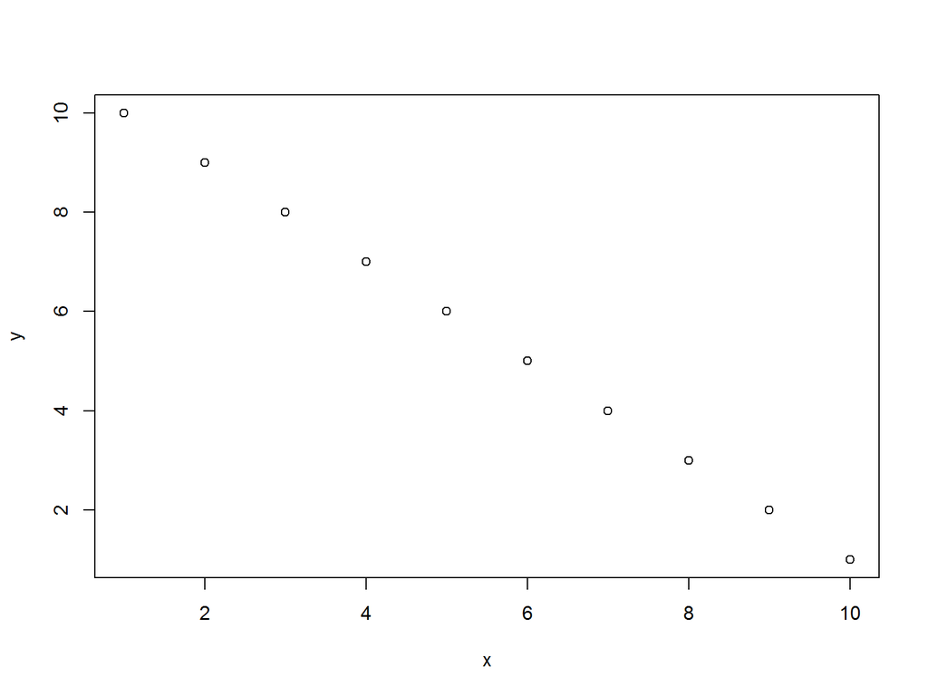

```r
x <- 1:10
y <- 10:1
plot(x,y)
```

- **`mynum2`를 X로, `mynum3`를 Y로 하여 plot을 그려보세요**

# 실습문제

1. Vector `num`에 0부터 1001사이의 데이터 삽입하기
   - 첫째 줄은 2의 배수, 둘째 줄은 4의 배수, 셋째 줄은 5의 배수, 넷째 줄은 6의 배수로 생성하기
2. Vector `num`에 총 몇개의 데이터가 있는지 출력하기
3. Vector `num`의 평균값 바로 뒤 순서에 숫자 10000 삽입하기
4. Vector `num`의 평균값보다 큰 데이터들을 출력
5. Vector `num`을 내림차순으로 정렬해서 `num1`에 입력하기
6. Vector `num1`에 간단한 summary 적용하기
7. Vector `num`을 x축으로 `num1`을 y축으로 Plot 그리기
8. `color`변수를 만들어서 5개의 색상을 넣고, 해당 색상을 가진 과일들을 이름으로 넣기